# R Notebook

```r
library(readr)
library(ggplot2)
library(dplyr)
library(corrplot)
library(corrplot)
library(caret)
library(forecast)
```

Cargar dataset

```r
sales <- read_csv('supermarket_db.csv', show_col_types = FALSE)
#head(df)
summary(df)
```

[output not shown]

Exploracion de los datos

```r
media_total <- mean(sales$Total)
cat("El monto total por transacción es", media_total)
```

```
El monto total por transacción es 322.9667
```

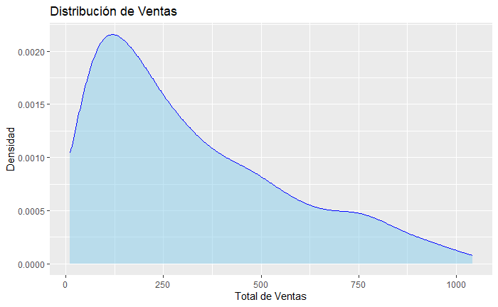

```r
ggplot(sales, aes(x = Total)) +
  geom_density(fill = "skyblue", color = "blue", alpha = 0.5) +
  labs(title = "Distribución de Ventas",
       x = "Total de Ventas",
       y = "Densidad")
```

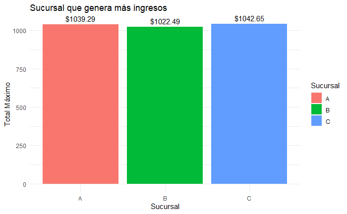

```r
branch_summary <- sales %>%
  group_by(Branch) %>%
  summarise(Max_Total = max(Total), Transaction_Count = n())

# Crear un gráfico de barras
ggplot(branch_summary, aes(x = Branch, y = Max_Total, fill = Branch)) +
  geom_bar(stat = "identity", position = "dodge") +
  geom_text(aes(label = sprintf("$%.2f", Max_Total)), vjust = -0.5, position = position_dodge(width = 1)) +
  labs(title = "Sucursal que genera más ingresos",
       x = "Sucursal",
       y = "Total Máximo",
       fill = "Sucursal") +
  theme_minimal()
```

Satisfaccion de clientes.

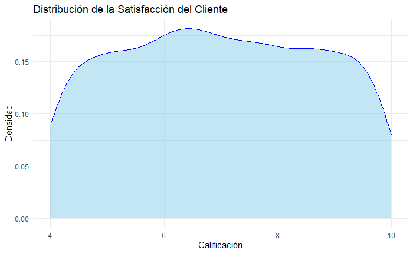

```r
ggplot(sales, aes(x = Rating)) +
  geom_density(fill = "skyblue", color = "blue", alpha = 0.5) +
  labs(title = "Distribución de la Satisfacción del Cliente",
       x = "Calificación",
       y = "Densidad") +
  theme_minimal()
```

Producto mas popular en Enero

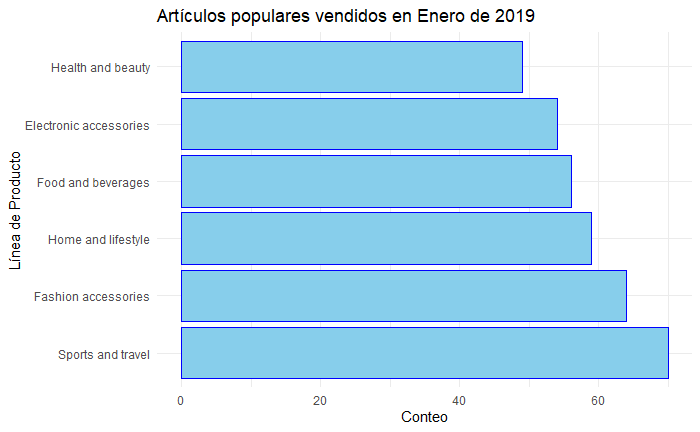

```r
sales$Date <- as.Date(sales$Date, format = "%m/%d/%Y")

# Filtrar por enero
sales_january <- sales[sales$Date >= as.Date("2019-01-01") & sales$Date <= as.Date("2019-01-31"), ]

product_counts <- sales_january %>%
  group_by(`Product line`) %>%
  summarise(Count = n())

# Ordenar el dataframe por la frecuencia en orden descendente
product_counts <- product_counts[order(-product_counts$Count), ]

# Crear un gráfico de barras horizontales
ggplot(product_counts, aes(x = Count, y = reorder(`Product line`, -Count))) +
  geom_bar(stat = "identity", fill = "skyblue", color = "blue") +
  labs(title = "Artículos populares vendidos en Enero de 2019",
       x = "Conteo",
       y = "Línea de Producto") +
  theme_minimal()
```

Productos mas populares en Febrero

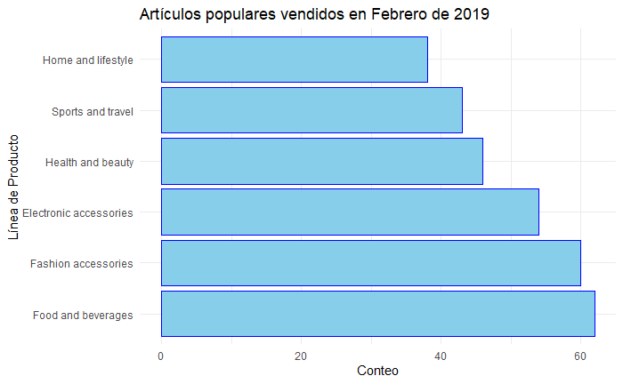

```r
# Filtrar por febrero
sales_february <- sales[sales$Date >= as.Date("2019-02-01") & sales$Date <= as.Date("2019-02-28"), ]

product_counts_february <- sales_february %>%
  group_by(`Product line`) %>%
  summarise(Count = n())

product_counts_february <- product_counts_february[order(-product_counts_february$Count), ]

# Crear un gráfico de barras horizontales
ggplot(product_counts_february, aes(x = Count, y = reorder(`Product line`, -Count))) +
  geom_bar(stat = "identity", fill = "skyblue", color = "blue") +
  labs(title = "Artículos populares vendidos en Febrero de 2019",
       x = "Conteo",
       y = "Línea de Producto") +
  theme_minimal()
```

Productos más vendidos en Marzo

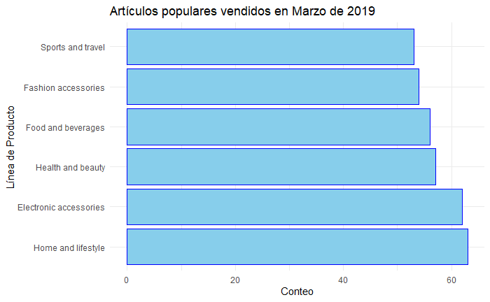

```r
# Filtrar por febrero
sales_march <- sales[sales$Date >= as.Date("2019-03-01") & sales$Date <= as.Date("2019-03-31"), ]

product_counts_march <- sales_march %>%
  group_by(`Product line`) %>%
  summarise(Count = n())

product_counts_march <- product_counts_march[order(-product_counts_march$Count), ]

# Crear un gráfico de barras horizontales
ggplot(product_counts_march, aes(x = Count, y = reorder(`Product line`, -Count))) +
  geom_bar(stat = "identity", fill = "skyblue", color = "blue") +
  labs(title = "Artículos populares vendidos en Marzo de 2019",
       x = "Conteo",
       y = "Línea de Producto") +
  theme_minimal()
```

Grafico de densidad del total de ventas hechas en Enero

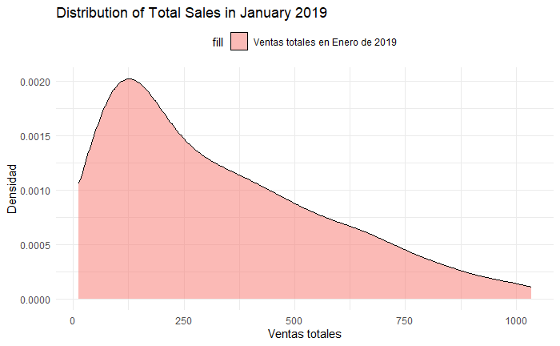

```r
ggplot(sales_january, aes(x = Total, fill = "Ventas totales en Enero de 2019")) +
  geom_density(alpha = 0.5) +
  labs(title = "Distribution of Total Sales in January 2019",
       x = "Ventas totales",
       y = "Densidad") +
  theme_minimal() +
  theme(legend.position = "top")
```

El resultado del analisis de densidad nos muestra que los datos estan sesgados hacia los valores entre 0 y 260 en su mayoria, por lo que hay mas brobabilidad de que las personas relicen compras totales en ese rango de precio.

Vamos a analizar la variable Total con respecto a la variable Date mediante un analisis de series temporales.

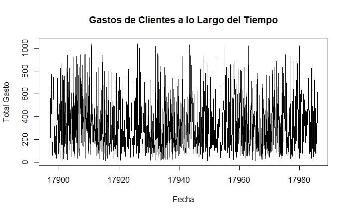

```r
#Formatear las fechas de la base de datos
sales$Date <- as.Date(sales$Date, format = "%m/%d/%Y")
#Creamos una serie temporal con la variable Total
time_series_data <- ts(sales$Total, start = c(min(sales$Date), 1), end = c(max(sales$Date), 12), frequency = 12)
# Plotear la serie temporal
plot(time_series_data, main = "Gastos de Clientes a lo Largo del Tiempo", xlab = "Fecha", ylab = "Total Gasto")
```

Descomponer la serie temporal En el paso de descomposición de la serie temporal, se utiliza la función decompose() para separar la serie temporal en tres componentes principales: tendencia (trend), estacionalidad (seasonal), y residuos (remainder o random). Estos componentes proporcionan información sobre cómo la serie temporal cambia a lo largo del tiempo y ayudan a entender patrones subyacentes.

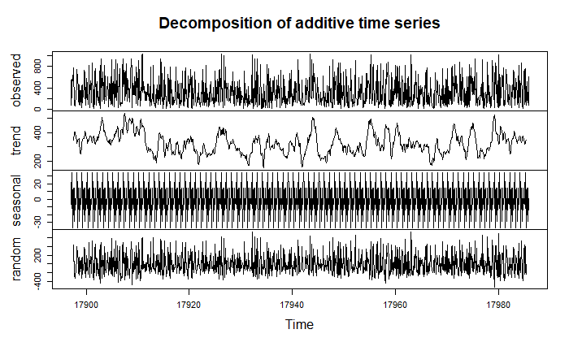

```r
#Descomponer la serie temporal
decomposed <- decompose(time_series_data)
plot(decomposed)
```

Ahora intentraemos pronosticar datos futuros en los proximos 12 periodos

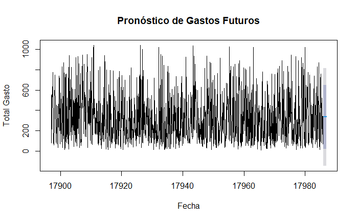

```r
forecast_data <- forecast(time_series_data, h = 12)

plot(forecast_data, main = "Pronóstico de Gastos Futuros", xlab = "Fecha", ylab = "Total Gasto")
```

```r
# Filtrar datos para enero y febrero
sales_jan_feb <- sales[sales$Date >= as.Date("2019-01-01") & sales$Date <= as.Date("2019-02-28"), ]

# Crear una serie temporal
sales_ts <- ts(sales_jan_feb$Total, frequency = 1)  # Ajustar la frecuencia correctamente

# Pronosticar datos futuros para marzo
forecast_data <- forecast(sales_ts, h = 1)  # Pronosticar para 1 periodo (marzo)

# Obtener la fecha correspondiente a marzo
fecha_marzo <- sales[sales$Date == as.Date("2019-03-01"), ]$Date

# Agregar fecha al pronóstico
forecast_data <- cbind(fecha = fecha_marzo, as.data.frame(forecast_data))
# Comparar con datos reales de marzo
sales_mar <- sales[sales$Date >= as.Date("2019-03-01") & sales$Date <= as.Date("2019-03-31"), ]

# Mostrar comparación
comparison <- data.frame(Real = sales_mar$Total, Predicho = forecast_data$mean)
```

[output not shown]